# Take-home Exercise 1: Geospatial Analytics for Public Safety

First- and second-order point-pattern analysis of VIIRS active-fire detections in Pulang Pisau Regency, Central Kalimantan, 1 July to 25 September 2026

## Contents

One argument running through all of it: a satellite hotspot is not a fire, and almost everything I did follows from taking that seriously.

1. The place, the data, and the window
2. Why a detection is not a fire
3. Where it burns
4. When it burns, and what the orbit decides
5. Two nulls: one meaningless, one that can fail
6. Space and time are not separable
7. What the clustering is organised around, and how big it is
8. The correction that reframes it all
9. What the analysis says about fire here
10. What I would take from this

## 1. The place, the data, and the window

413,182

rows downloaded

34,987

inside the regency

10,321

burned 375 m cells

87

days analysed

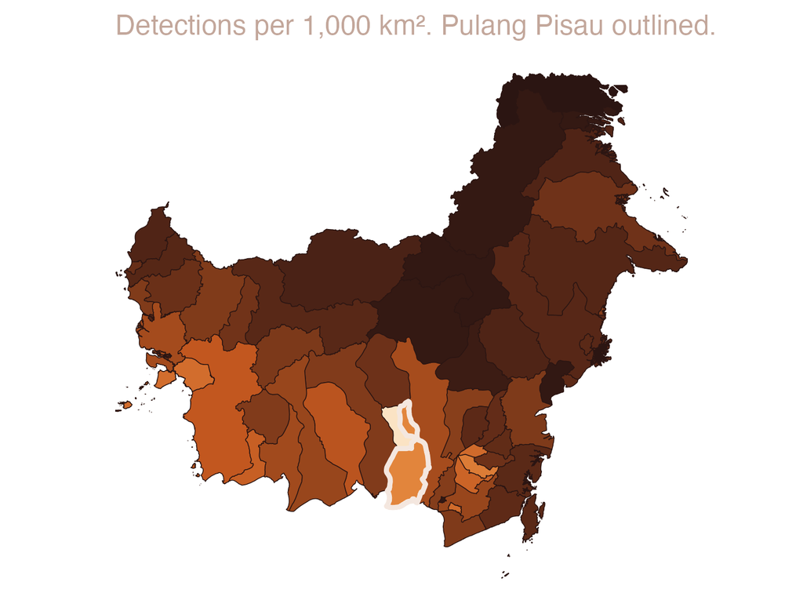

## 2. A detection is not a fire

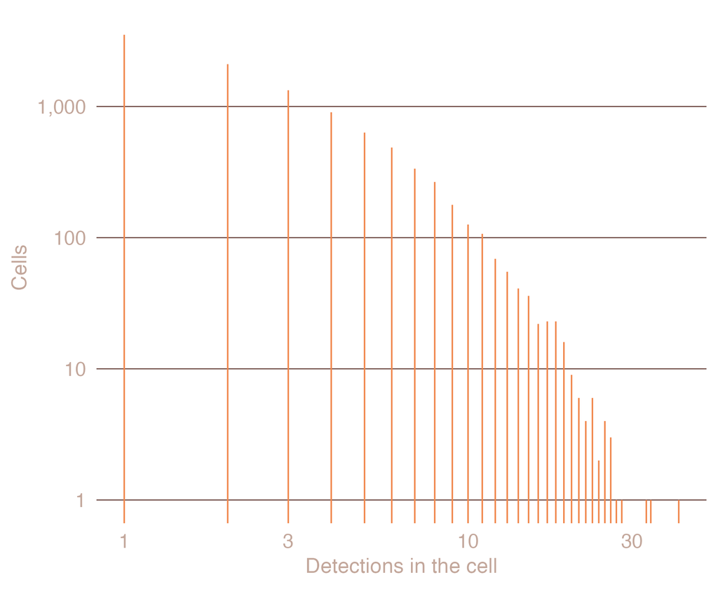

## 3. Where it burns

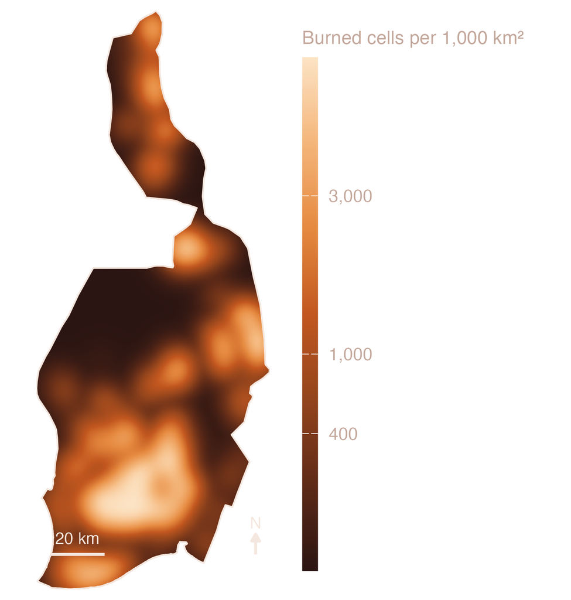

## 4. When it burns, and what the orbit decides

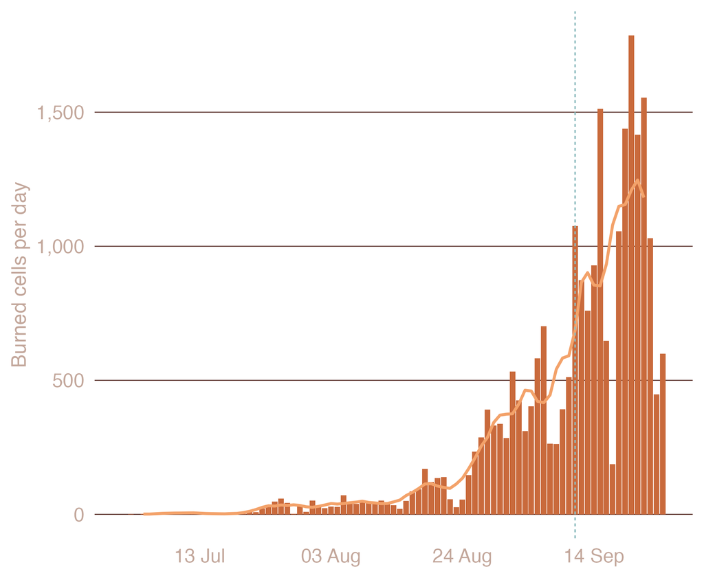

## 5. Two nulls: one meaningless, one that can fail

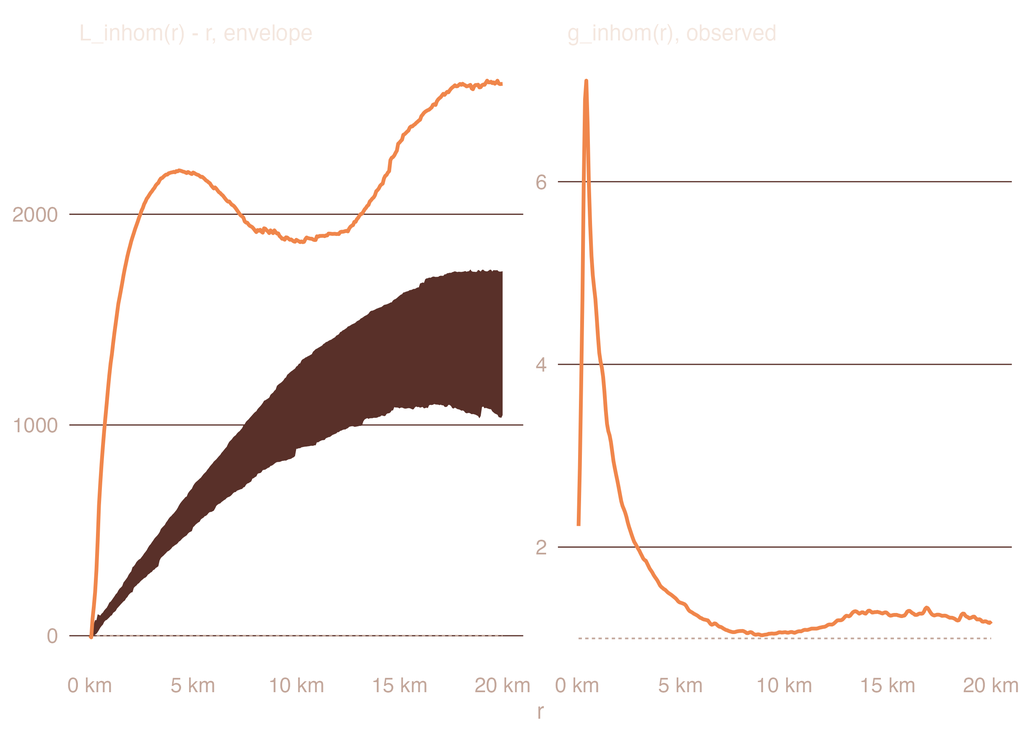

## 6. Space and time are not separable

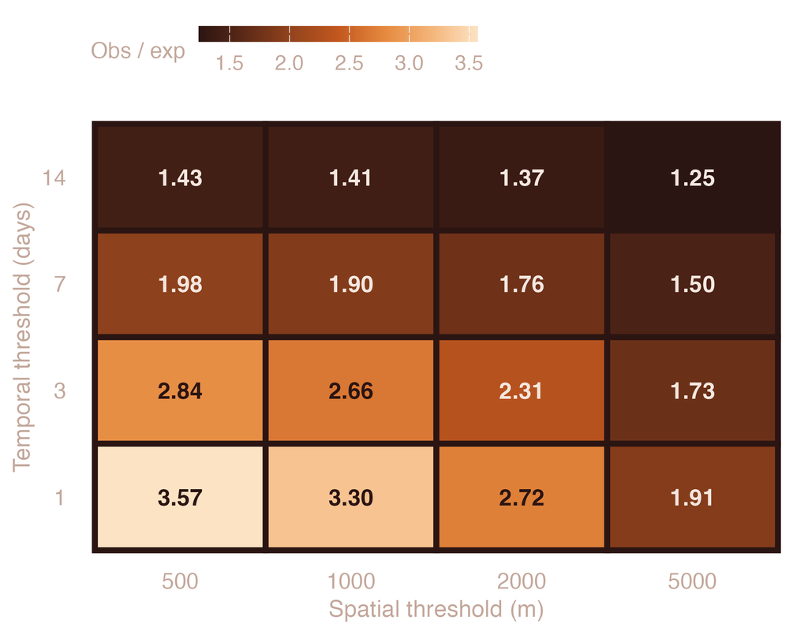

## 7. What it is organised around, and how big it is

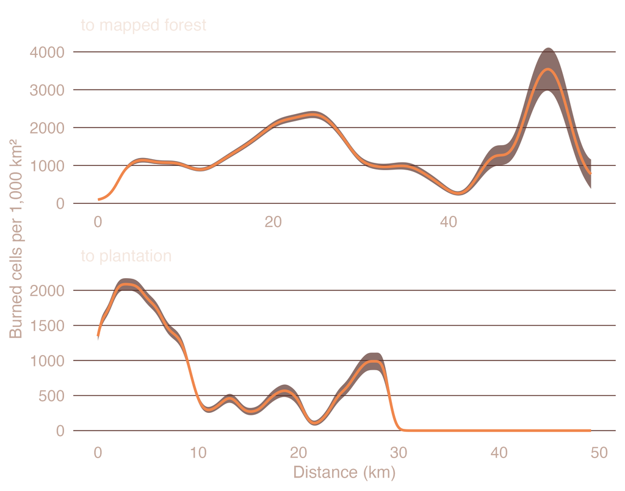

## 8. The correction that reframes it all

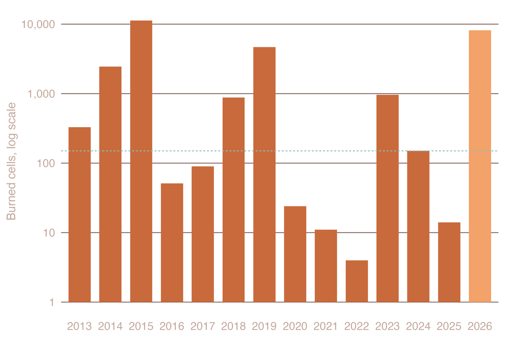

## 9. What the analysis says about fire here

**Fire is concentrated, not spread.** Two orders of magnitude separate the southern peat belt from the northern interior. Capability placed in proportion to sub-district area sits mostly where fire is not.

## 10. What I would take from this

3.4x

inflation in the raw count

438 m

peak of residual clustering

0.9 to 1.03 km

cluster scale, bootstrap interval

2 of 14

2026 rank in the record

What made the results credible

**Every result I would defend came from replacing a default null with one that could fail.** Complete spatial randomness rejects before I compute anything. Moran’s I on raw counts is 0.69. The short-range rose has eight lobes. None of those are findings: they are the instrument and the geometry, restated.

**Intensity** spans two orders of magnitude and is stable across four bandwidths. **Clustering** survives the inhomogeneous null and an areal method with different weights agrees. **Scale** is confirmed by two independent estimators. **Land cover** carries 3,204 of 3,550 AIC units from one term.

My technical report, code and audit trail are in the repository. Data: NASA FIRMS, geoBoundaries, OpenStreetMap via Geofabrik.